# Fish Whole School Data

Sets up the functions that will be used later

```r
rad2deg <- function(rad) {(rad * 180) / (pi)}
deg2rad <- function(deg) {(deg * pi) / (180)}
round_any <- function(x, accuracy, f=round){f(x/ accuracy) * accuracy}
ang_mean <- function(x){rad2deg(atan(mean(sin(deg2rad(x)))/mean(cos(deg2rad(x)))))}

fold_angle_0_360_to_0_180 <- function(x){abs(abs(x-180)-180)}

fold_angle_neg_180_180_to_neg_90_90 <- function(x){ifelse(x > 90,90-abs(90-x),ifelse(x < -90, -90+abs(-90-x), x))}

min_n <- function(x,n){sort(x)[1:n]}
max_n <- function(x,n){sort(x,decreasing = TRUE)[1:n]}

substrRight <- function(x, n){
  substr(x, nchar(x)-n+1, nchar(x))
}

tailbeat_len = 19
```

Reads in the data and alters it as needed

```r
school_data <- read.csv("Fish_School_Values.csv")
school_data <- na.omit(school_data)

school_data <- school_data %>% mutate(Flow = ifelse(Flow == "0", "Still Water", "Flowing Water (2 BL/s)")) %>%
                           mutate(Ablation = ifelse(Ablation == "N", "No Ablation", "Ablated")) %>%
                           mutate(Darkness = ifelse(Darkness == "N", "Light", "Dark")) %>%
                           filter(School_Speed < 7) %>%
                           mutate(Flow = factor(Flow), Ablation = factor(Ablation), Darkness = factor(Darkness)) %>%
                           mutate(Flow = fct_relevel(Flow, c("Still Water","Flowing Water (2 BL/s)"))) %>%
                           mutate(Ablation = fct_relevel(Ablation, c("No Ablation","Ablated"))) %>%
                           mutate(Darkness = fct_relevel(Darkness, c("Light","Dark"))) %>%
                           mutate(Flow_Ablation_Darkness = factor(paste(Flow,Ablation,Darkness,sep=", ")))
```

Let’s make some models

```r
school_speed_anova <- aov(School_Speed ~ Flow + Ablation + Darkness + Flow:Ablation + Flow:Darkness, data = school_data)

Anova(school_speed_anova)
```

```
Anova Table (Type II tests)

Response: School_Speed
              Sum Sq  Df F value  Pr(>F)
Flow          155.61   1 87.2871 < 2e-16 ***
Ablation        2.92   1  1.6378 0.20117
Darkness      145.45   1 81.5871 < 2e-16 ***
Flow:Ablation   9.13   1  5.1201 0.02404 *
Flow:Darkness   1.43   1  0.8048 0.37004
Residuals     980.50 550
---
Signif. codes:  0 ‘***’ 0.001 ‘**’ 0.01 ‘*’ 0.05 ‘.’ 0.1 ‘ ’ 1
```

```r
school_tbf_anova <- aov(School_TB_Freq ~ Flow + Ablation + Darkness + Flow:Ablation + Flow:Darkness, data = school_data)

Anova(school_tbf_anova)
```

```
Anova Table (Type II tests)

Response: School_TB_Freq
               Sum Sq  Df F value    Pr(>F)
Flow           34.142   1 76.7360 < 2.2e-16 ***
Ablation        0.271   1  0.6080    0.4359
Darkness        9.837   1 22.1103 3.259e-06 ***
Flow:Ablation   0.380   1  0.8543    0.3557
Flow:Darkness   1.080   1  2.4272    0.1198
Residuals     244.709 550
---
Signif. codes:  0 ‘***’ 0.001 ‘**’ 0.01 ‘*’ 0.05 ‘.’ 0.1 ‘ ’ 1
```

```r
school_polar_anova <- aov(School_Polar ~ Flow + Ablation + Darkness + Flow:Ablation + Flow:Darkness, data = school_data)

Anova(school_polar_anova)
```

```
Anova Table (Type II tests)

Response: School_Polar
               Sum Sq  Df F value  Pr(>F)
Flow           0.0176   1  0.8979 0.34375
Ablation       0.0102   1  0.5197 0.47129
Darkness       0.0405   1  2.0705 0.15075
Flow:Ablation  0.0927   1  4.7314 0.03004 *
Flow:Darkness  0.0144   1  0.7376 0.39079
Residuals     10.7706 550
---
Signif. codes:  0 ‘***’ 0.001 ‘**’ 0.01 ‘*’ 0.05 ‘.’ 0.1 ‘ ’ 1
```

```r
school_nnd_anova <- aov(NND ~ Flow + Ablation + Darkness + Flow:Ablation + Flow:Darkness, data = school_data)

Anova(school_nnd_anova)
```

```
Anova Table (Type II tests)

Response: NND
              Sum Sq  Df  F value  Pr(>F)
Flow           0.219   1   2.2097 0.13772
Ablation       0.020   1   0.2037 0.65194
Darkness      26.820   1 270.1966 < 2e-16 ***
Flow:Ablation  0.301   1   3.0344 0.08207 .
Flow:Darkness  0.033   1   0.3314 0.56507
Residuals     54.593 550
---
Signif. codes:  0 ‘***’ 0.001 ‘**’ 0.01 ‘*’ 0.05 ‘.’ 0.1 ‘ ’ 1
```

```r
school_area_anova <- aov(Area ~ Flow + Ablation + Darkness + Flow:Ablation + Flow:Darkness, data = school_data)

Anova(school_area_anova)
```

```
Anova Table (Type II tests)

Response: Area
              Sum Sq  Df  F value  Pr(>F)
Flow             9.3   1   1.5390 0.21529
Ablation         8.2   1   1.3519 0.24545
Darkness      1146.9   1 189.9220 < 2e-16 ***
Flow:Ablation    0.4   1   0.0580 0.80984
Flow:Darkness   20.5   1   3.3992 0.06577 .
Residuals     3321.3 550
---
Signif. codes:  0 ‘***’ 0.001 ‘**’ 0.01 ‘*’ 0.05 ‘.’ 0.1 ‘ ’ 1
```

Now let’s make some plots

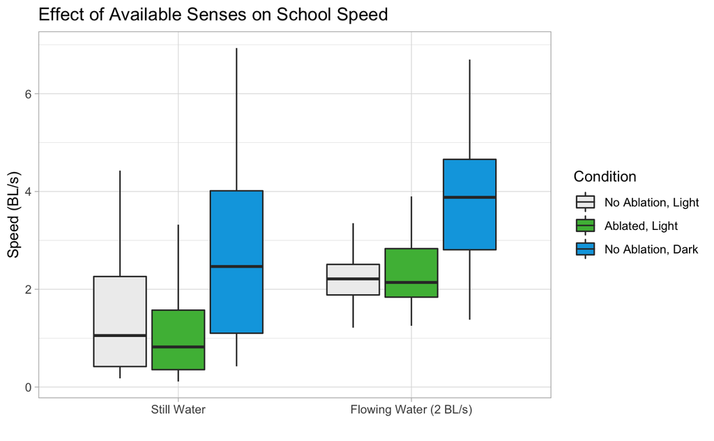

```r
ggplot(school_data, aes(x = Flow, y = School_Speed, fill = interaction(Ablation,Darkness,sep=", ")))+
  geom_boxplot(outlier.shape = NA) +
  guides(fill = guide_legend(title = "Condition")) +
  scale_fill_manual(values=c("#EEEEEE", "#4CB944", "#00A7E1")) +
  ggtitle("Effect of Available Senses on School Speed") +
  xlab("") +
  ylab("Speed (BL/s)") +
  theme_light()
```

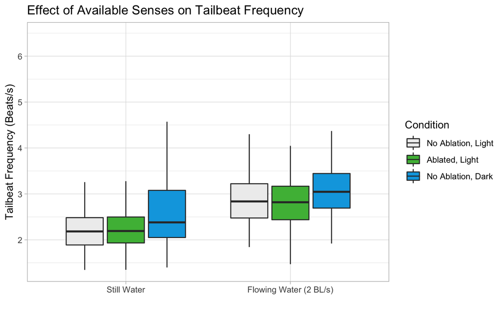

```r
ggplot(school_data, aes(x = Flow, y = School_TB_Freq, fill = interaction(Ablation,Darkness,sep=", ")))+
  geom_boxplot(outlier.shape = NA) +
  guides(fill = guide_legend(title = "Condition")) +
  scale_fill_manual(values=c("#EEEEEE", "#4CB944", "#00A7E1")) +
  ggtitle("Effect of Available Senses on Tailbeat Frequency") +
  xlab("") +
  ylab("Tailbeat Frequency (Beats/s)") +
  theme_light()
```

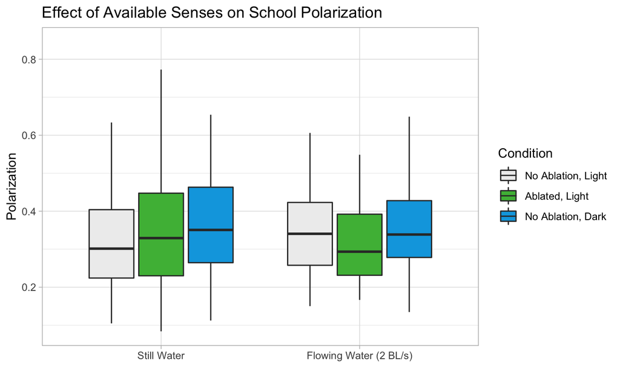

```r
ggplot(school_data, aes(x = Flow, y = School_Polar, fill = interaction(Ablation,Darkness,sep=", ")))+
  geom_boxplot(outlier.shape = NA) +
  guides(fill = guide_legend(title = "Condition")) +
  scale_fill_manual(values=c("#EEEEEE", "#4CB944", "#00A7E1")) +
  ggtitle("Effect of Available Senses on School Polarization") +
  xlab("") +
  ylab("Polarization") +
  theme_light()
```

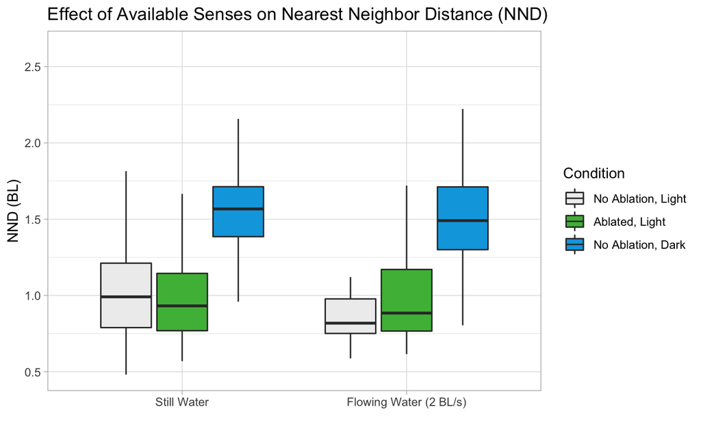

```r
ggplot(school_data, aes(x = Flow, y = NND, fill = interaction(Ablation,Darkness,sep=", ")))+
  geom_boxplot(outlier.shape = NA) +
  guides(fill = guide_legend(title = "Condition")) +
  scale_fill_manual(values=c("#EEEEEE", "#4CB944", "#00A7E1")) +
  ggtitle("Effect of Available Senses on Nearest Neighbor Distance (NND)") +
  xlab("") +
  ylab("NND (BL)") +
  theme_light()
```

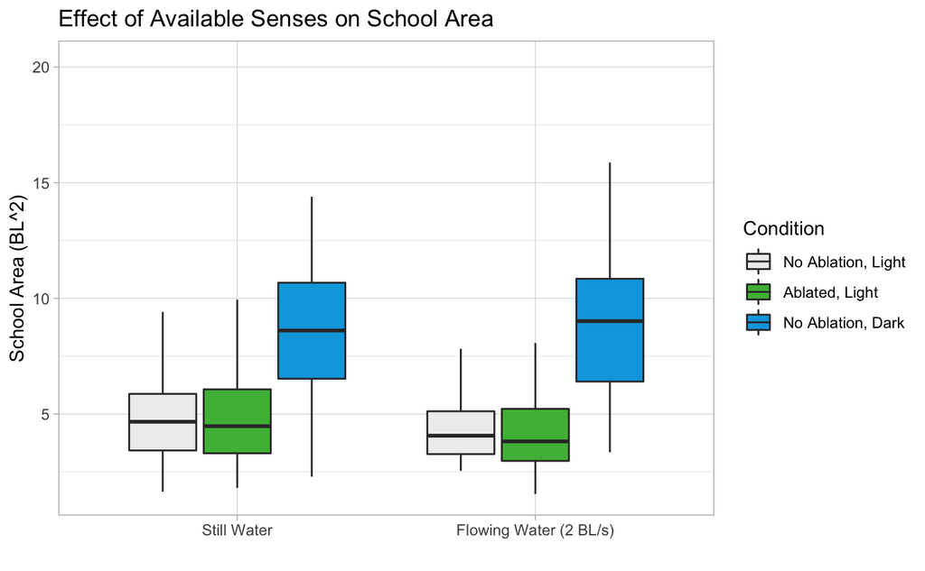

```r
ggplot(school_data, aes(x = Flow, y = Area, fill = interaction(Ablation,Darkness,sep=", ")))+
  geom_boxplot(outlier.shape = NA) +
  guides(fill = guide_legend(title = "Condition")) +
  scale_fill_manual(values=c("#EEEEEE", "#4CB944", "#00A7E1")) +
  ggtitle("Effect of Available Senses on School Area") +
  xlab("") +
  ylab("School Area (BL^2)") +
  theme_light()
```

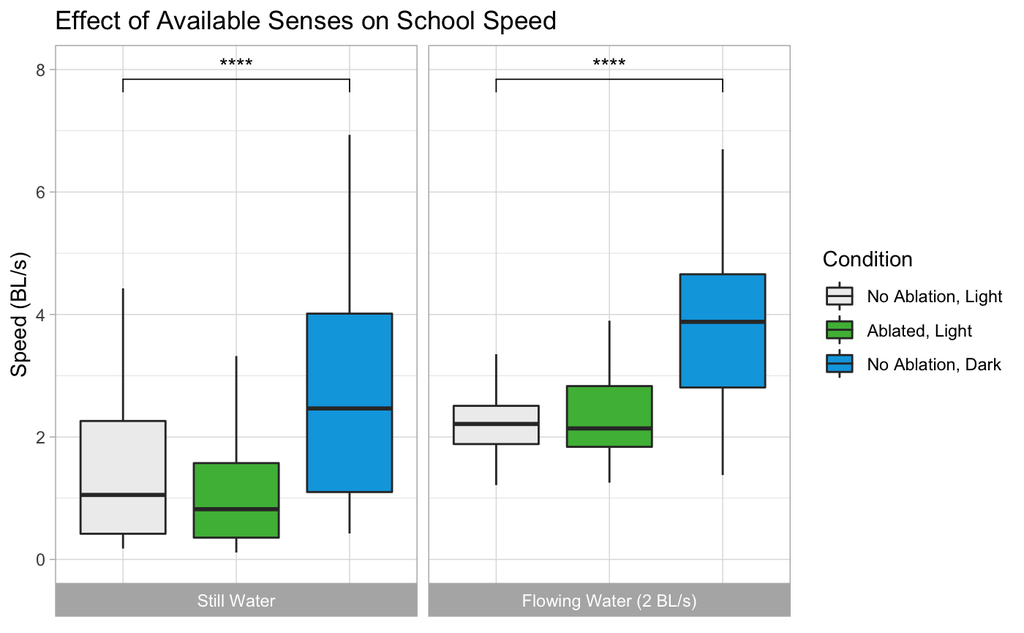

```r
my_comparisons <- list( c("No Ablation, Light", "No Ablation, Dark"))

ggplot(school_data, aes(x = interaction(Ablation,Darkness,sep=", "), y = School_Speed, fill = interaction(Ablation,Darkness,sep=", ")))+
  geom_boxplot(outlier.shape = NA) +
  guides(fill = guide_legend(title = "Condition")) +
  scale_fill_manual(values=c("#EEEEEE", "#4CB944", "#00A7E1")) +
  ggtitle("Effect of Available Senses on School Speed") +
  xlab("") +
  ylab("Speed (BL/s)") +
  ylim(0,8) +
  theme_light() +
  facet_wrap(~ Flow, strip.position = "bottom")+
  #stat_compare_means(aes(label = ..p.signif..), method = "t.test", ref.group = "Flow 0, No Ablation, Light")
  stat_compare_means(comparisons = my_comparisons, label.y = c(7.5,8.5), label = "p.signif", hide.ns = TRUE) +
  theme(axis.title.x=element_blank(),
        axis.text.x=element_blank(),
        axis.ticks.x=element_blank())
```

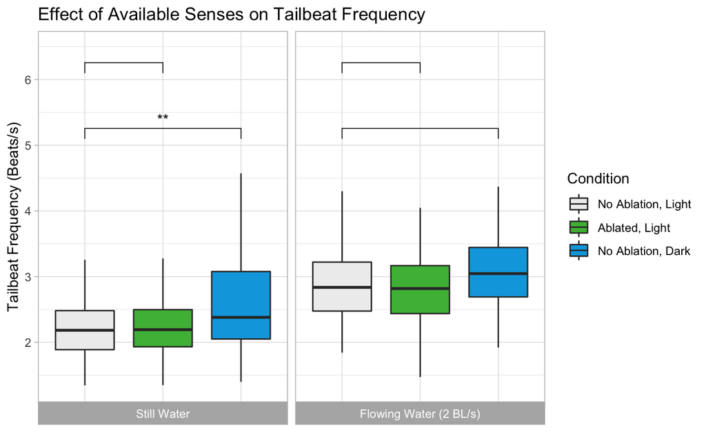

```r
my_comparisons <- list( c("No Ablation, Light", "No Ablation, Dark"), c("No Ablation, Light", "Ablated, Light") )

ggplot(school_data, aes(x = interaction(Ablation,Darkness,sep=", "), y = School_TB_Freq, fill = interaction(Ablation,Darkness,sep=", ")))+
  geom_boxplot(outlier.shape = NA) +
  guides(fill = guide_legend(title = "Condition")) +
  scale_fill_manual(values=c("#EEEEEE", "#4CB944", "#00A7E1")) +
  ggtitle("Effect of Available Senses on Tailbeat Frequency") +
  xlab("") +
  ylab("Tailbeat Frequency (Beats/s)") +
  theme_light() +
  facet_wrap(~ Flow, strip.position = "bottom")+
  #stat_compare_means(aes(label = ..p.signif..), method = "t.test", ref.group = "Flow 0, No Ablation, Light")
  stat_compare_means(comparisons = my_comparisons, label.y = c(5,6), label = "p.signif", hide.ns = TRUE) +
  theme(axis.title.x=element_blank(),
        axis.text.x=element_blank(),
        axis.ticks.x=element_blank())
```

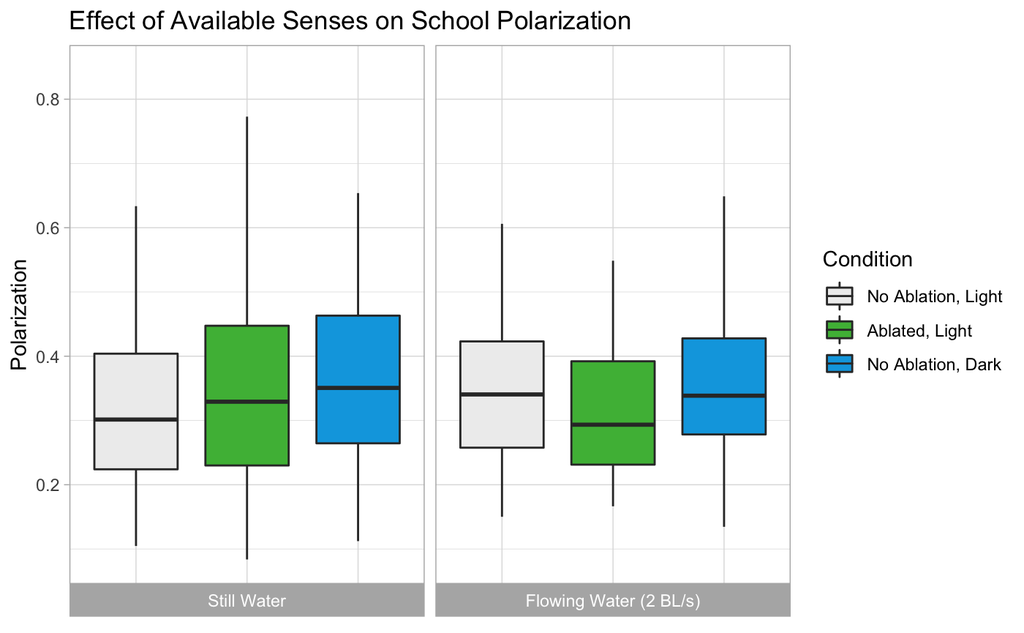

```r
my_comparisons <- list( c("No Ablation, Light", "No Ablation, Dark"), c("No Ablation, Light", "Ablated, Light") )

ggplot(school_data, aes(x = interaction(Ablation,Darkness,sep=", "), y = School_Polar, fill = interaction(Ablation,Darkness,sep=", ")))+
  geom_boxplot(outlier.shape = NA) +
  guides(fill = guide_legend(title = "Condition")) +
  scale_fill_manual(values=c("#EEEEEE", "#4CB944", "#00A7E1")) +
  ggtitle("Effect of Available Senses on School Polarization") +
  xlab("") +
  ylab("Polarization") +
  theme_light() +
  facet_wrap(~ Flow, strip.position = "bottom")+
  #stat_compare_means(aes(label = ..p.signif..), method = "t.test", ref.group = "Flow 0, No Ablation, Light")
  #stat_compare_means(comparisons = my_comparisons, label.y = c(1, 1.25), label = "p.signif", hide.ns = TRUE) +
  theme(axis.title.x=element_blank(),
        axis.text.x=element_blank(),
        axis.ticks.x=element_blank())
```

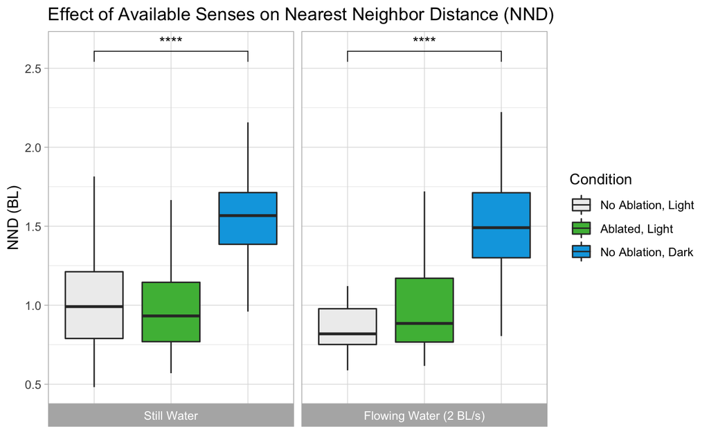

```r
my_comparisons <- list( c("No Ablation, Light", "No Ablation, Dark"))

ggplot(school_data, aes(x = interaction(Ablation,Darkness,sep=", "), y = NND, fill = interaction(Ablation,Darkness,sep=", ")))+
  geom_boxplot(outlier.shape = NA) +
  guides(fill = guide_legend(title = "Condition")) +
  scale_fill_manual(values=c("#EEEEEE", "#4CB944", "#00A7E1")) +
  ggtitle("Effect of Available Senses on Nearest Neighbor Distance (NND)") +
  xlab("") +
  ylab("NND (BL)") +
  theme_light() +
  facet_wrap(~ Flow, strip.position = "bottom")+
  #stat_compare_means(aes(label = ..p.signif..), method = "t.test", ref.group = "Flow 0, No Ablation, Light")
  stat_compare_means(comparisons = my_comparisons, label.y = c(2.5), label = "p.signif", hide.ns = TRUE) +
  theme(axis.title.x=element_blank(),
        axis.text.x=element_blank(),
        axis.ticks.x=element_blank())
```

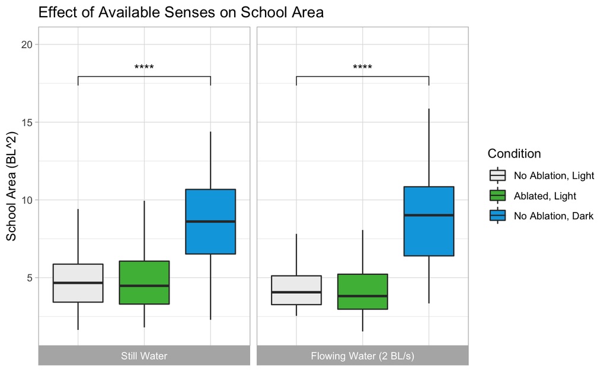

```r
my_comparisons <- list( c("No Ablation, Light", "No Ablation, Dark"))

ggplot(school_data, aes(x = interaction(Ablation,Darkness,sep=", "), y = Area, fill = interaction(Ablation,Darkness,sep=", ")))+
  geom_boxplot(outlier.shape = NA) +
  guides(fill = guide_legend(title = "Condition")) +
  scale_fill_manual(values=c("#EEEEEE", "#4CB944", "#00A7E1")) +
  ggtitle("Effect of Available Senses on School Area") +
  xlab("") +
  ylab("School Area (BL^2)") +
  theme_light() +
  facet_wrap(~ Flow, strip.position = "bottom")+
  #stat_compare_means(aes(label = ..p.signif..), method = "t.test", ref.group = "Flow 0, No Ablation, Light")
  stat_compare_means(comparisons = my_comparisons, label.y = c(17), label = "p.signif", hide.ns = TRUE) +
  theme(axis.title.x=element_blank(),
        axis.text.x=element_blank(),
        axis.ticks.x=element_blank())
```

```r
n = 100

school_sum <- school_data %>% group_by(Flow,Darkness,Ablation) %>%
                              summarise(x_sd = mean(X_SD), y_sd = mean(Y_SD)) %>%
                              ungroup()
school_sum_rep <- school_data %>% group_by(Flow,Darkness,Ablation) %>%
                              summarise(x_sd = mean(X_SD), y_sd = mean(Y_SD)) %>%
                              ungroup() %>%
                              slice(rep(1:n(), each = n)) %>%
                              group_by(Flow,Darkness,Ablation) %>%
                              mutate(angle = seq(0,2*pi,length.out=n)) %>%
                              ungroup() %>%
                              mutate(oval_x = x_sd*cos(angle), oval_y = y_sd*sin(angle))
```

[output not shown]

So now we’re reading in the raw between fish comparisons in order to do the binning of polarization and speed diffs by distance

```r
raw_school_data <- read.csv("Fish_Raw_Comp_Values.csv")
raw_school_data <- na.omit(raw_school_data)

raw_school_data <- raw_school_data %>% mutate(Flow = ifelse(Flow == "0", "Still Water", "Flowing Water (2 BL/s)")) %>%
                           mutate(Ablation = ifelse(Ablation == "N", "No Ablation", "Ablated")) %>%
                           mutate(Darkness = ifelse(Darkness == "N", "Light", "Dark")) %>%
                           mutate(Flow = factor(Flow), Ablation = factor(Ablation), Darkness = factor(Darkness)) %>%
                           mutate(Flow = fct_relevel(Flow, c("Still Water","Flowing Water (2 BL/s)"))) %>%
                           mutate(Ablation = fct_relevel(Ablation, c("No Ablation","Ablated"))) %>%
                           mutate(Darkness = fct_relevel(Darkness, c("Light","Dark"))) %>%
                           mutate(Flow_Ablation_Darkness = factor(paste(Flow,Ablation,Darkness,sep=", "))) %>%
                           separate(Fish, c("Fish1", "Fish2"),sep="x")

raw_school_data_fish_switch <- raw_school_data %>% mutate(Fish3 = Fish1) %>%
                                                   mutate(Fish1 = Fish2) %>%
                                                   mutate(Fish2 = Fish3) %>%
                                                   select(-c(Fish3))

raw_school_data_both_fish <- bind_rows(raw_school_data, raw_school_data_fish_switch)
```

Now let’s do the actually binning, mutating, and calculations

```r
tailbeat_len = 19

raw_school_binned <- raw_school_data %>% mutate(Round_Dist = round_any(Distance, 1)) %>%
                                         group_by(Year, Month, Day, Trial, Flow, Ablation, Darkness, Frame_Num, Round_Dist) %>%
                                         summarise(Mean_Speed_Diff = mean(Speed_Diff),
                                                   Polarization = (1/(2*n()))*sqrt(sum(sin(deg2rad(c(Fish1_Heading,Fish2_Heading))))**2 +
                                                                               sum(cos(deg2rad(c(Fish1_Heading,Fish2_Heading))))**2 ),
                                                   Count = n()) %>%
                                         ungroup() %>%
                                         mutate(Tailbeat = round_any(Frame_Num, tailbeat_len)/tailbeat_len+1) %>%
                                         group_by(Year, Month, Day, Trial, Flow, Ablation, Darkness, Tailbeat, Round_Dist) %>%
                                         summarise(Mean_Speed_Diff = mean(Mean_Speed_Diff),
                                                   Polarization = mean(Polarization),
                                                   Count = sum(Count)) %>%
                                         ungroup() %>%
                                         filter(Round_Dist <= 3) %>%
                                         mutate(Round_Dist = as.factor(Round_Dist))
```

```r
binned_speed_dist_aov <- aov(Mean_Speed_Diff ~ Round_Dist*(Flow + Ablation + Darkness + Flow:Ablation + Flow:Darkness), data = raw_school_binned)

Anova(binned_speed_dist_aov)
```

```
Anova Table (Type II tests)

Response: Mean_Speed_Diff
                         Sum Sq   Df F value   Pr(>F)
Round_Dist                 1.11    3  0.8617 0.460322
Flow                       0.29    1  0.6866 0.407429
Ablation                   1.82    1  4.2514 0.039376 *
Darkness                   0.05    1  0.1145 0.735070
Flow:Ablation              1.97    1  4.5979 0.032158 *
Flow:Darkness              0.98    1  2.2901 0.130394
Round_Dist:Flow            4.80    3  3.7296 0.010921 *
Round_Dist:Ablation        0.93    3  0.7266 0.536108
Round_Dist:Darkness        5.57    3  4.3267 0.004784 **
Round_Dist:Flow:Ablation   1.76    3  1.3700 0.250238
Round_Dist:Flow:Darkness   0.55    3  0.4294 0.731968
Residuals                702.91 1639
---
Signif. codes:  0 ‘***’ 0.001 ‘**’ 0.01 ‘*’ 0.05 ‘.’ 0.1 ‘ ’ 1
```

```r
binned_polar_dist_aov <- aov(Polarization ~ Round_Dist*(Flow + Ablation + Darkness + Flow:Ablation + Flow:Darkness), data = raw_school_binned)

Anova(binned_polar_dist_aov)
```

```
Anova Table (Type II tests)

Response: Polarization
                         Sum Sq   Df F value    Pr(>F)
Round_Dist                2.346    3 15.7743 4.092e-10 ***
Flow                      0.053    1  1.0748  0.300024
Ablation                  0.459    1  9.2586  0.002381 **
Darkness                  0.029    1  0.5755  0.448209
Flow:Ablation             0.190    1  3.8290  0.050542 .
Flow:Darkness             0.139    1  2.8047  0.094180 .
Round_Dist:Flow           0.161    3  1.0837  0.354827
Round_Dist:Ablation       0.186    3  1.2492  0.290417
Round_Dist:Darkness       0.168    3  1.1280  0.336444
Round_Dist:Flow:Ablation  0.416    3  2.7976  0.038886 *
Round_Dist:Flow:Darkness  0.086    3  0.5796  0.628429
Residuals                81.246 1639
---
Signif. codes:  0 ‘***’ 0.001 ‘**’ 0.01 ‘*’ 0.05 ‘.’ 0.1 ‘ ’ 1
```

```r
ggplot(raw_school_binned, aes(x = Round_Dist, y = Polarization, fill = interaction(Ablation,Darkness,sep=", ")))+
  geom_boxplot(outlier.shape = NA) +
  guides(fill = guide_legend(title = "Condition")) +
  scale_fill_manual(values=c("#EEEEEE", "#4CB944", "#00A7E1")) +
  ggtitle("Effect of Distance and Available Senses on Polarization") +
  facet_wrap(~ Flow) +
  xlab("") +
  ylab("Polarization (BL)") +
  ylim(0,1) +
  theme_light()
```

```r
ggplot(raw_school_binned, aes(x = Round_Dist, y = abs(Mean_Speed_Diff), fill = interaction(Ablation,Darkness,sep=", ")))+
  geom_boxplot(outlier.shape = NA) +
  guides(fill = guide_legend(title = "Condition")) +
  scale_fill_manual(values=c("#EEEEEE", "#4CB944", "#00A7E1")) +
  ggtitle("Effect of Distance and Available Senses on Speed Difference") +
  facet_wrap(~ Flow + Ablation + Darkness) +
  xlab("") +
  ylab("Speed Difference (BL/s)") +
  ylim(0,2) +
  theme_light()
```

Let’s look at polarization just less than 2 BL away

```r
raw_school_less_2BL <- raw_school_data %>% filter(Distance <= 2) %>%
                                         group_by(Year, Month, Day, Trial, Flow, Ablation, Darkness, Frame_Num) %>%
                                         summarise(Mean_Speed_Diff = mean(Speed_Diff),
                                                   Polarization = (1/(2*n()))*sqrt(sum(sin(deg2rad(c(Fish1_Heading,Fish2_Heading))))**2 +
                                                                               sum(cos(deg2rad(c(Fish1_Heading,Fish2_Heading))))**2 ),
                                                   Count = n()) %>%
                                         ungroup() %>%
                                         mutate(Tailbeat = round_any(Frame_Num, tailbeat_len)/tailbeat_len+1) %>%
                                         group_by(Year, Month, Day, Trial, Flow, Ablation, Darkness, Tailbeat) %>%
                                         summarise(Mean_Speed_Diff = mean(Mean_Speed_Diff),
                                                   Polarization = mean(Polarization),
                                                   Count = sum(Count)) %>%
                                         ungroup()
```

```r
school_polar_anova_2BL <- aov(Polarization ~ Flow + Ablation + Darkness + Flow:Ablation + Flow:Darkness, data = raw_school_less_2BL)

Anova(school_polar_anova_2BL)
```

```
Anova Table (Type II tests)

Response: Polarization
               Sum Sq  Df F value  Pr(>F)
Flow           0.0119   1  0.2857 0.59322
Ablation       0.1054   1  2.5316 0.11223
Darkness       0.0036   1  0.0867 0.76852
Flow:Ablation  0.1192   1  2.8629 0.09127 .
Flow:Darkness  0.0776   1  1.8646 0.17272
Residuals     20.4840 492
---
Signif. codes:  0 ‘***’ 0.001 ‘**’ 0.01 ‘*’ 0.05 ‘.’ 0.1 ‘ ’ 1
```

```r
ggplot(raw_school_less_2BL, aes(x = Flow, y = Polarization, fill = interaction(Ablation,Darkness,sep=", ")))+
  geom_boxplot(outlier.shape = NA) +
  guides(fill = guide_legend(title = "Condition")) +
  scale_fill_manual(values=c("#EEEEEE", "#4CB944", "#00A7E1")) +
  ggtitle("Effect of Available Senses on School Polarization") +
  xlab("") +
  ylab("Polarization") +
  theme_light()
```

```r
school_dist_props <- raw_school_data %>% mutate(Tailbeat = round_any(Frame_Num, tailbeat_len)/tailbeat_len+1) %>%
                                         group_by(Year, Month, Day, Trial, Flow, Ablation, Darkness, Tailbeat) %>%
                                         summarise(P_LE_1 = sum(Distance <= 1) / n() * 100,
                                                   P_LE_2 = sum(Distance <= 2) / n() * 100,
                                                   P_LE_3 = sum(Distance <= 3) / n() * 100)
ggplot(school_dist_props, aes(x = Flow, y = P_LE_1, fill = interaction(Ablation,Darkness,sep=", ")))+
  geom_boxplot(outlier.shape = NA) +
  guides(fill = guide_legend(title = "Condition")) +
  scale_fill_manual(values=c("#EEEEEE", "#4CB944", "#00A7E1")) +
  ggtitle("Percent of Fish Within 1 BL") +
  xlab("") +
  ylab("Percent (%)") +
  theme_light()
```

```r
ggplot(school_dist_props, aes(x = Flow, y = P_LE_2, fill = interaction(Ablation,Darkness,sep=", ")))+
  geom_boxplot(outlier.shape = NA) +
  guides(fill = guide_legend(title = "Condition")) +
  scale_fill_manual(values=c("#EEEEEE", "#4CB944", "#00A7E1")) +
  ggtitle("Percent of Fish Within 2 BL") +
  xlab("") +
  ylab("Percent (%)") +
  theme_light()
```

```r
ggplot(school_dist_props, aes(x = Flow, y = P_LE_3, fill = interaction(Ablation,Darkness,sep=", ")))+
  geom_boxplot(outlier.shape = NA) +
  guides(fill = guide_legend(title = "Condition")) +
  scale_fill_manual(values=c("#EEEEEE", "#4CB944", "#00A7E1")) +
  ggtitle("Percent of Fish Within 3 BL") +
  xlab("") +
  ylab("Percent (%)") +
  theme_light()
```

Now let’s try and show if they form small groupings, or if they are just spaced out more We’re going to plot distance to each neighbor on average

```r
d_to_each_neighbor <- raw_school_data_both_fish %>% mutate(Tailbeat = round_any(Frame_Num, tailbeat_len)/tailbeat_len+1) %>%
                                          group_by(Year, Month, Day, Trial, Flow, Ablation, Darkness, Frame_Num, Fish1) %>%
                                          mutate(Neighbor_Num = min_rank(Distance)) %>%
                                          ungroup() %>%
                                          group_by(Year, Month, Day, Trial, Flow, Ablation, Darkness, Neighbor_Num) %>%
                                          summarise(Neighbor_Dist = mean(Distance))
```

```r
ggplot(d_to_each_neighbor %>% filter(Neighbor_Num <= 3), aes(x = as.factor(Neighbor_Num), y = Neighbor_Dist, fill = interaction(Ablation,Darkness,sep=", ")))+
  geom_boxplot() +
  guides(fill = guide_legend(title = "Condition")) +
  scale_fill_manual(values=c("#EEEEEE", "#4CB944", "#00A7E1")) +
  facet_wrap(~ Flow) +
  ggtitle("Distance to Each Neighboring Fish") +
  xlab("") +
  ylab("Distance (BL)") +
  theme_light()
```

Okay. Better idea. Let’s see where the biggest distance difference is between fish! So if they are all evenly spaced you would see that the largest difference would be randomly between any of them. If they tend to be between the second closest and third then you’ll see it skewed smaller.

```r
min_diff_dist_neighbor <- raw_school_data_both_fish %>% mutate(Tailbeat = round_any(Frame_Num, tailbeat_len)/tailbeat_len+1) %>%
                                              group_by(Year, Month, Day, Trial, Flow, Ablation, Darkness, Frame_Num, Fish1) %>%
                                              arrange(Distance) %>%
                                              mutate(Neighbor_Dist_Diff = lead(Distance) - Distance) %>%
                                              slice_max(order_by = Neighbor_Dist_Diff) %>%
                                              ungroup() %>%
                                              mutate(Biggest_Diff_Neighbor = as.numeric(substrRight(Fish2,1))) %>%
                                              group_by(Year, Month, Day, Trial, Flow, Ablation, Darkness, Tailbeat) %>%
                                              summarise(Biggest_Diff_Neighbor_Mean_Log = exp(mean(log(Biggest_Diff_Neighbor), na.rm = TRUE))) %>%
                                              ungroup()
```

```r
ggplot(min_diff_dist_neighbor, aes(x = Flow, y = Biggest_Diff_Neighbor_Mean_Log, fill = interaction(Ablation,Darkness,sep=", ")))+
  geom_violin() +
  guides(fill = guide_legend(title = "Condition")) +
  scale_fill_manual(values=c("#EEEEEE", "#4CB944", "#00A7E1")) +
  ggtitle("Average Neighbor with the Largest Difference in Distance") +
  xlab("") +
  ylab("Neighbor Number") +
  theme_light()
```

In the end this has not been helpful. Or they are all the same, but I think the bounded data makes this difficult. I’m not sure what this really shows in the end. I thought it would show a clearer pattern, but they all seem to be about the same. So this says that most often the largest jump is between the 4th and 5th. But how can that go both ways?

What if instead we look at the percent of time there is only 1, 2 etc fish within 2 BL?

```r
count_within_2 <- raw_school_data_both_fish %>% mutate(Tailbeat = round_any(Frame_Num, tailbeat_len)/tailbeat_len+1) %>%
                                                group_by(Year, Month, Day, Trial, Flow, Ablation, Darkness, Tailbeat, Frame_Num, Fish1) %>%
                                                summarise(Only_2_Fish_in_2BL = ifelse(sum(Distance <= 2) <= 1, 1, 0)) %>%
                                                ungroup() %>%
                                                group_by(Year, Month, Day, Trial, Flow, Ablation, Darkness, Tailbeat) %>%
                                                summarise(Percent_Only_2_Fish_in_2BL = sum(Only_2_Fish_in_2BL)/n() * 100) %>%
                                                ungroup()
```

```
can override using the `.groups` argument.
```

```r
percent_with_2BL_aov <- aov(Percent_Only_2_Fish_in_2BL ~ Flow + Ablation + Darkness + Flow:Ablation + Flow:Darkness, data = count_within_2)
Anova(percent_with_2BL_aov)
```

```
Anova Table (Type II tests)

Response: Percent_Only_2_Fish_in_2BL
              Sum Sq  Df F value    Pr(>F)
Flow            6269   1  6.8047  0.009359 **
Ablation        1296   1  1.4070  0.236104
Darkness       83112   1 90.2094 < 2.2e-16 ***
Flow:Ablation    310   1  0.3367  0.561973
Flow:Darkness    175   1  0.1896  0.663425
Residuals     468953 509
---
Signif. codes:  0 ‘***’ 0.001 ‘**’ 0.01 ‘*’ 0.05 ‘.’ 0.1 ‘ ’ 1
```

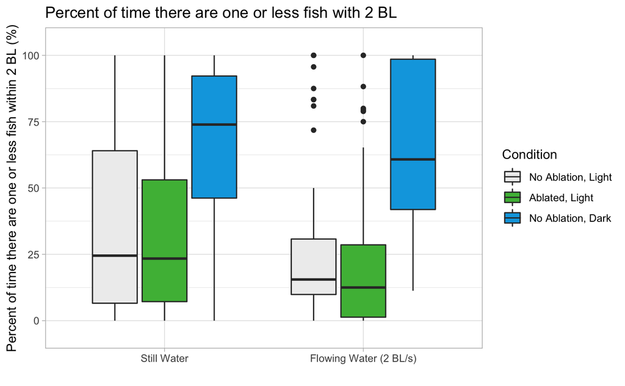

```r
ggplot(count_within_2, aes(x = Flow, y = Percent_Only_2_Fish_in_2BL, fill = interaction(Ablation,Darkness,sep=", ")))+
  geom_boxplot() +
  guides(fill = guide_legend(title = "Condition")) +
  scale_fill_manual(values=c("#EEEEEE", "#4CB944", "#00A7E1")) +
  ggtitle("Percent of time there are one or less fish with 2 BL") +
  xlab("") +
  ylab("Percent of time there are one or less fish within 2 BL (%)") +
  ylim(-5,105) +
  theme_light()
```

Now we are looking at the percent of time there is just 1 fish within 2 BL

```r
only_1_within_2 <- raw_school_data_both_fish %>% mutate(Tailbeat = round_any(Frame_Num, tailbeat_len)/tailbeat_len+1) %>%
                                                group_by(Year, Month, Day, Trial, Flow, Ablation, Darkness, Tailbeat, Frame_Num, Fish1) %>%
                                                summarise(Only_1_Fish_in_2BL = ifelse(sum(Distance <= 2) == 1, 1, 0)) %>%
                                                ungroup() %>%
                                                group_by(Year, Month, Day, Trial, Flow, Ablation, Darkness, Tailbeat) %>%
                                                summarise(Percent_Only_1_Fish_in_2BL = sum(Only_1_Fish_in_2BL)/n() * 100) %>%
                                                ungroup()
only_1_within_2_aov <- aov(Percent_Only_1_Fish_in_2BL ~ Flow + Ablation + Darkness + Flow:Ablation + Flow:Darkness, data = only_1_within_2)
Anova(only_1_within_2_aov)
```

```
Anova Table (Type II tests)

Response: Percent_Only_1_Fish_in_2BL
              Sum Sq  Df F value    Pr(>F)
Flow            7400   1 17.5962 3.222e-05 ***
Ablation        1699   1  4.0410   0.04493 *
Darkness        6623   1 15.7481 8.276e-05 ***
Flow:Ablation      6   1  0.0147   0.90362
Flow:Darkness    390   1  0.9268   0.33616
Residuals     214056 509
---
Signif. codes:  0 ‘***’ 0.001 ‘**’ 0.01 ‘*’ 0.05 ‘.’ 0.1 ‘ ’ 1
```

```r
ggplot(only_1_within_2, aes(x = Flow, y = Percent_Only_1_Fish_in_2BL, fill = interaction(Ablation,Darkness,sep=", ")))+
  geom_boxplot() +
  guides(fill = guide_legend(title = "Condition")) +
  scale_fill_manual(values=c("#EEEEEE", "#4CB944", "#00A7E1")) +
  ggtitle("Percent of time there is just one other fish within 2 BL") +
  xlab("") +
  ylab("Percent of time there is just one other fish within 2 BL(%)") +
  ylim(-5,105) +
  theme_light()
```

```r
only_0_within_2 <- raw_school_data_both_fish %>% mutate(Tailbeat = round_any(Frame_Num, tailbeat_len)/tailbeat_len+1) %>%
                                                group_by(Year, Month, Day, Trial, Flow, Ablation, Darkness, Tailbeat, Frame_Num, Fish1) %>%
                                                summarise(Only_0_Fish_in_2BL = ifelse(sum(Distance <= 2) == 0, 1, 0)) %>%
                                                ungroup() %>%
                                                group_by(Year, Month, Day, Trial, Flow, Ablation, Darkness, Tailbeat) %>%
                                                summarise(Percent_Only_0_Fish_in_2BL = sum(Only_0_Fish_in_2BL)/n() * 100) %>%
                                                ungroup()
only_0_within_2_aov <- aov(Percent_Only_0_Fish_in_2BL ~ Flow + Ablation + Darkness + Flow:Ablation + Flow:Darkness, data = only_0_within_2)
Anova(only_0_within_2_aov)
```

```
Anova Table (Type II tests)

Response: Percent_Only_0_Fish_in_2BL
              Sum Sq  Df F value Pr(>F)
Flow              47   1  0.0942 0.7590
Ablation          27   1  0.0548 0.8150
Darkness       42812   1 86.1063 <2e-16 ***
Flow:Ablation    229   1  0.4604 0.4978
Flow:Darkness   1086   1  2.1848 0.1400
Residuals     253076 509
---
Signif. codes:  0 ‘***’ 0.001 ‘**’ 0.01 ‘*’ 0.05 ‘.’ 0.1 ‘ ’ 1
```

```r
ggplot(only_0_within_2, aes(x = Flow, y = Percent_Only_0_Fish_in_2BL, fill = interaction(Ablation,Darkness,sep=", ")))+
  geom_boxplot() +
  guides(fill = guide_legend(title = "Condition")) +
  scale_fill_manual(values=c("#EEEEEE", "#4CB944", "#00A7E1")) +
  ggtitle("Percent of time there are one or less fish with 2 BL") +
  xlab("") +
  ylab("Percent of time there are one or less fish within 2 BL (%)") +
  ylim(-5,105) +
  theme_light()
```

```r
count_within_2 <- raw_school_data_both_fish %>% mutate(Tailbeat = round_any(Frame_Num, tailbeat_len)/tailbeat_len+1) %>%
                                                group_by(Year, Month, Day, Trial, Flow, Ablation, Darkness, Tailbeat, Frame_Num, Fish1) %>%
                                                summarise(Count_Fish_in_2BL = sum(Distance <= 2)) %>%
                                                ungroup() %>%
                                                group_by(Year, Month, Day, Trial, Flow, Ablation, Darkness, Tailbeat) %>%
                                                summarise(Mean_Count_Fish_in_2BL = mean(Count_Fish_in_2BL)) %>%
                                                ungroup()
```

```
can override using the `.groups` argument.
```

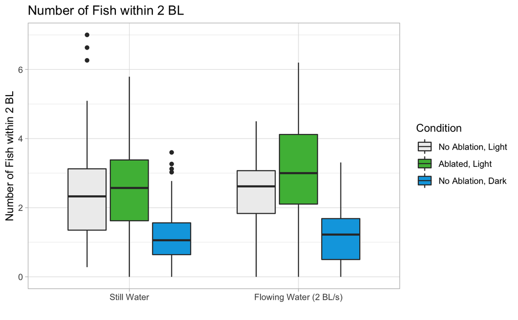

```r
ggplot(count_within_2, aes(x = Flow, y = Mean_Count_Fish_in_2BL, fill = interaction(Ablation,Darkness,sep=", ")))+
  geom_boxplot() +
  guides(fill = guide_legend(title = "Condition")) +
  scale_fill_manual(values=c("#EEEEEE", "#4CB944", "#00A7E1")) +
  ggtitle("Number of Fish within 2 BL") +
  xlab("") +
  ylab("Number of Fish within 2 BL") +
  theme_light()
```

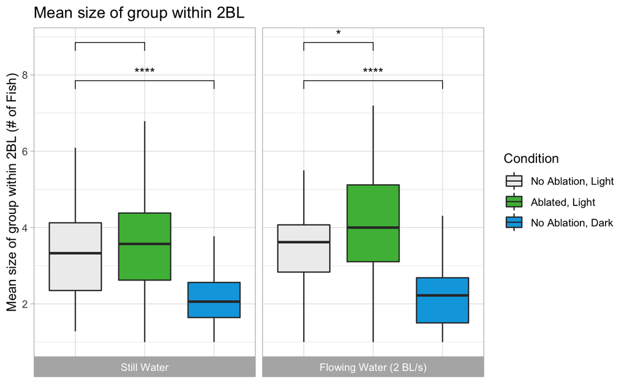

```r
my_comparisons <- list( c("No Ablation, Light", "No Ablation, Dark"), c("No Ablation, Light", "Ablated, Light") )

ggplot(count_within_2,
       aes(x = interaction(Ablation,Darkness,sep=", "), y = Mean_Count_Fish_in_2BL+1,
           fill = interaction(Ablation,Darkness,sep=", ")))+
  geom_boxplot(outlier.shape = NA) +
  guides(fill = guide_legend(title = "Condition")) +
  scale_fill_manual(values=c("#EEEEEE", "#4CB944", "#00A7E1")) +
  ggtitle("Mean size of group within 2BL") +
  xlab("") +
  ylab("Mean size of group within 2BL (# of Fish)") +
  ylim(0,9) +
  theme_light() +
  facet_wrap(~ Flow, strip.position = "bottom")+
  #stat_compare_means(aes(label = ..p.signif..), method = "t.test", ref.group = "Flow 0, No Ablation, Light")
  stat_compare_means(comparisons = my_comparisons, label.y = c(7.5,8.5), label = "p.signif", hide.ns = TRUE) +
  theme(axis.title.x=element_blank(),
        axis.text.x=element_blank(),
        axis.ticks.x=element_blank()) +
  scale_y_continuous(breaks=c(0,2,4,6,8))
```

```r
only_n_within_2 <- raw_school_data_both_fish %>% mutate(Tailbeat = round_any(Frame_Num, tailbeat_len)/tailbeat_len+1) %>%
                                                group_by(Year, Month, Day, Trial, Flow, Ablation, Darkness, Tailbeat, Frame_Num, Fish1) %>%
                                                summarise(Only_0_Fish_in_2BL = ifelse(sum(Distance <= 2) == 0, 1, 0),
                                                          Only_1_Fish_in_2BL = ifelse(sum(Distance <= 2) == 1, 1, 0),
                                                          Only_2_Fish_in_2BL = ifelse(sum(Distance <= 2) == 2, 1, 0),
                                                          Only_3_Fish_in_2BL = ifelse(sum(Distance <= 2) == 3, 1, 0),
                                                          Only_4_Fish_in_2BL = ifelse(sum(Distance <= 2) == 4, 1, 0),
                                                          Only_5_Fish_in_2BL = ifelse(sum(Distance <= 2) == 5, 1, 0),
                                                          Only_6_Fish_in_2BL = ifelse(sum(Distance <= 2) == 6, 1, 0),
                                                          Only_7_Fish_in_2BL = ifelse(sum(Distance <= 2) == 6, 1, 0)) %>%
                                                ungroup() %>%
                                                pivot_longer(c(Only_0_Fish_in_2BL,Only_1_Fish_in_2BL,Only_2_Fish_in_2BL,Only_3_Fish_in_2BL,
                                                               Only_4_Fish_in_2BL,Only_5_Fish_in_2BL,Only_6_Fish_in_2BL,Only_7_Fish_in_2BL),
                                                             names_to = "Num_Fish_In_2_BL", values_to = "count") %>%
                                                mutate(Num_Fish_In_2_BL = gsub('Only_', '', gsub('_Fish_in_2BL', '', Num_Fish_In_2_BL))) %>%
                                                group_by(Flow, Ablation, Darkness, Num_Fish_In_2_BL) %>%
                                                summarise(Percent = sum(count)/n() * 100) %>%
                                                ungroup() %>%
                                                mutate(Num_Fish_In_2_BL = fct_rev(Num_Fish_In_2_BL))
```

```
can override using the `.groups` argument.
```

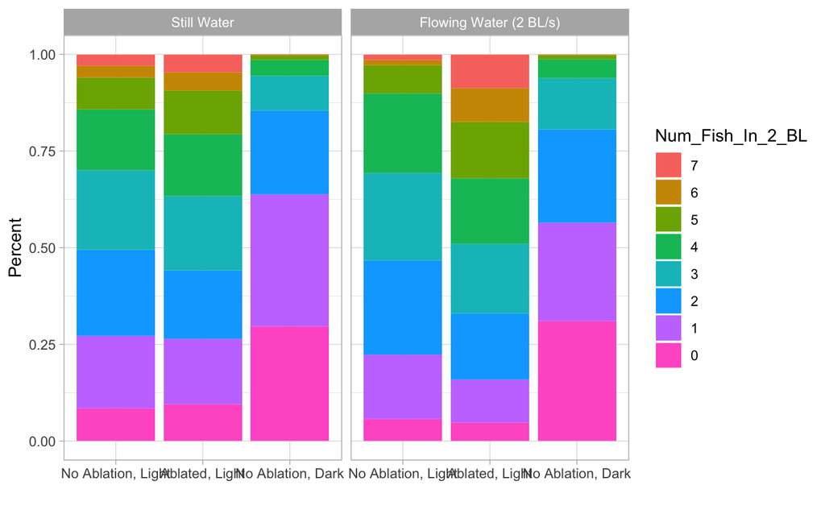

```r
ggplot(only_n_within_2, aes(y=Percent, x=interaction(Ablation,Darkness,sep=", "), fill = Num_Fish_In_2_BL)) +
    geom_bar(position="fill", stat="identity") +
    facet_wrap(~ Flow) +
    theme_light() +
    xlab("")
```

Calculating Group Speed over Individual Speed

```r
speed_whole_school <- school_data %>% rename(Tailbeat_Num = X)
```

[output not shown]

How many nearest neighbors do they have in one trial?

```r
num_neighbors_df_model_hist <- num_neighbors_df %>% group_by(Year, Month, Day, Trial, Fish1,
                                                             Flow, Ablation, Darkness, Flow_Ablation_Darkness,) %>%
                                                    summarize(n_neightbors = mean(n_neightbors))
```

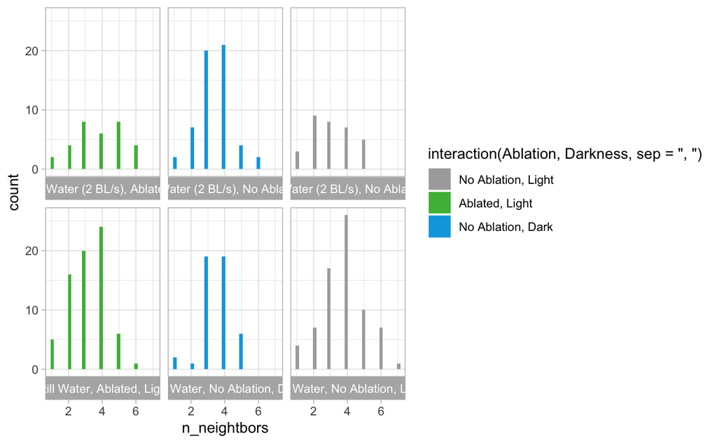

```r
ggplot(num_neighbors_df_model_hist, aes(x = n_neightbors, fill = interaction(Ablation,Darkness,sep=", ")))+
  geom_histogram() +
  scale_fill_manual(values=c("#AAAAAA", "#4CB944", "#00A7E1")) +
  facet_wrap(~ Flow_Ablation_Darkness, strip.position = "bottom")+
  theme_light()
```

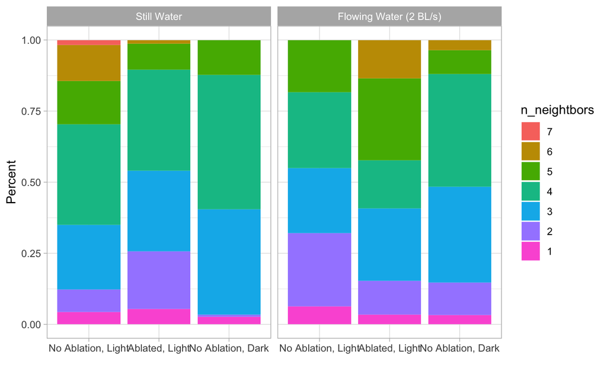

```r
ggplot(num_neighbors_for_bar_df, aes(y = Percent, x=interaction(Ablation,Darkness,sep=", "), fill = n_neightbors)) +
    geom_bar(position="fill", stat="identity") +
    facet_wrap(~ Flow) +
    theme_light() +
    xlab("")
```

model time?

```r
m0 <- glm(n_neightbors ~ 1, data = num_neighbors_df_model_hist)
m_f <- glm(n_neightbors ~ Flow, data = num_neighbors_df_model_hist)
m_a <- glm(n_neightbors ~ Ablation, data = num_neighbors_df_model_hist)
m_d <- glm(n_neightbors ~ Darkness, data = num_neighbors_df_model_hist)
m_f_a <- glm(n_neightbors ~ Flow*Ablation, data = num_neighbors_df_model_hist)
m_f_d <- glm(n_neightbors ~ Flow*Darkness, data = num_neighbors_df_model_hist)
m_a_d <- glm(n_neightbors ~ Ablation*Darkness, data = num_neighbors_df_model_hist)
m_f_a_d <- glm(n_neightbors ~ Flow*Ablation*Darkness, data = num_neighbors_df_model_hist)
best_groups <- glm(n_neightbors ~ 0+Flow:Ablation, data = num_neighbors_df_model_hist)


ICtab(m0,m_f,m_a,m_d,m_f_a,m_f_d,m_a_d,m_f_a_d)
```

```
        dAIC df
m_f_a    0.0 5
m_f_a_d  1.0 7
m0       6.9 2
m_a      7.9 3
m_f      8.7 3
m_d      8.9 3
m_a_d    9.7 4
m_f_d   12.5 5
```

```r
summary(m_f_a)
```

```
Call:
glm(formula = n_neightbors ~ Flow * Ablation, data = num_neighbors_df_model_hist)

Deviance Residuals:
    Min       1Q   Median       3Q      Max
-2.8125  -0.6891   0.1875   0.7620   3.3109

Coefficients:
                                           Estimate Std. Error t value Pr(>|t|)
(Intercept)                                  3.6891     0.1084  34.030  < 2e-16 ***
FlowFlowing Water (2 BL/s)                  -0.3936     0.1663  -2.367 0.018532 *
AblationAblated                             -0.5085     0.1766  -2.880 0.004256 **
FlowFlowing Water (2 BL/s):AblationAblated   1.0256     0.3013   3.404 0.000752 ***
---
Signif. codes:  0 ‘***’ 0.001 ‘**’ 0.01 ‘*’ 0.05 ‘.’ 0.1 ‘ ’ 1

(Dispersion parameter for gaussian family taken to be 1.398507)

    Null deviance: 447.52  on 310  degrees of freedom
Residual deviance: 429.34  on 307  degrees of freedom
AIC: 992.86

Number of Fisher Scoring iterations: 2
```

```r
summary(best_groups)
```

```
Call:
glm(formula = n_neightbors ~ 0 + Flow:Ablation, data = num_neighbors_df_model_hist)

Deviance Residuals:
    Min       1Q   Median       3Q      Max
-2.8125  -0.6891   0.1875   0.7620   3.3109

Coefficients:
                                               Estimate Std. Error t value Pr(>|t|)
FlowStill Water:AblationNo Ablation              3.6891     0.1084   34.03   <2e-16 ***
FlowFlowing Water (2 BL/s):AblationNo Ablation   3.2955     0.1261   26.14   <2e-16 ***
FlowStill Water:AblationAblated                  3.1806     0.1394   22.82   <2e-16 ***
FlowFlowing Water (2 BL/s):AblationAblated       3.8125     0.2091   18.24   <2e-16 ***
---
Signif. codes:  0 ‘***’ 0.001 ‘**’ 0.01 ‘*’ 0.05 ‘.’ 0.1 ‘ ’ 1

(Dispersion parameter for gaussian family taken to be 1.398507)

    Null deviance: 4198.00  on 311  degrees of freedom
Residual deviance:  429.34  on 307  degrees of freedom
AIC: 992.86

Number of Fisher Scoring iterations: 2
```

```r
Anova(m_f_a)
```

```
Analysis of Deviance Table (Type II tests)

Response: n_neightbors
              LR Chisq Df Pr(>Chisq)
Flow            0.3437  1  0.5577079
Ablation        1.1933  1  0.2746655
Flow:Ablation  11.5872  1  0.0006641 ***
---
Signif. codes:  0 ‘***’ 0.001 ‘**’ 0.01 ‘*’ 0.05 ‘.’ 0.1 ‘ ’ 1
```

Now 2BL with Simulated Data!

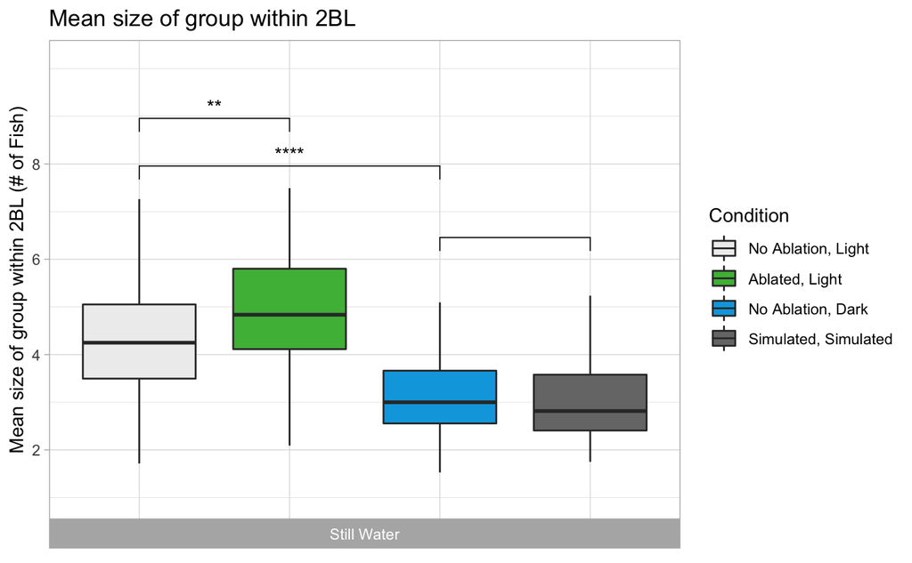

```r
ggplot(count_within_2_simul %>% filter(Flow == "Still Water"),
       aes(x = interaction(Ablation,Darkness,sep=", "), y = Mean_Count_Fish_in_2BL+1,
           fill = interaction(Ablation,Darkness,sep=", ")))+
  geom_boxplot(outlier.shape = NA) +
  guides(fill = guide_legend(title = "Condition")) +
  scale_fill_manual(values=c("#EEEEEE", "#4CB944", "#00A7E1","#777777")) +
  ggtitle("Mean size of group within 2BL") +
  xlab("") +
  ylab("Mean size of group within 2BL (# of Fish)") +
  ylim(0,9) +
  theme_light() +
  facet_wrap(~ Flow, strip.position = "bottom")+
  #stat_compare_means(aes(label = ..p.signif..), method = "t.test", ref.group = "Flow 0, No Ablation, Light")
  stat_compare_means(comparisons = my_comparisons, label.y = c(7.5,8.5,6), label = "p.signif", hide.ns = TRUE) +
  theme(axis.title.x=element_blank(),
        axis.text.x=element_blank(),
        axis.ticks.x=element_blank()) +
  scale_y_continuous(breaks=c(0,2,4,6,8))
```

#### Now trying to see how long fish stay within 2 BL in the different conditions.

```r
time_within_2_simul <- raw_school_data_simul_both_fish %>% filter(Distance <= 2) %>%
                                                           group_by(Year, Month, Day, Trial, Fish1, Fish2) %>%
                                                           mutate(frame_diff = Frame_Num - lag(Frame_Num)) %>%
                                                           mutate(frame_diff = ifelse(is.na(frame_diff), 1, frame_diff)) %>%
                                                           #This next line adds a grouping variable by keeping all the values after a jump in frame
                                                           # larger, and the same as each other
                                                           mutate(frame_grouper = cumsum(frame_diff) - 0:(n()-1)) %>%
                                                           group_by(Year, Month, Day, Trial, Ablation, Darkness, Fish1, Fish2, frame_grouper) %>%
                                                           #mutate(Together_Secs = max(Frame_Num) - min(Frame_Num))
                                                           #group_by(Year, Month, Day, Trial, Ablation, Darkness, Fish1, Fish2, frame_grouper) %>%
                                                           #The mean is just to make it into one number, it's all the same
                                                           summarize(Together_Secs = max((max(Frame_Num) - min(Frame_Num))/60))
```

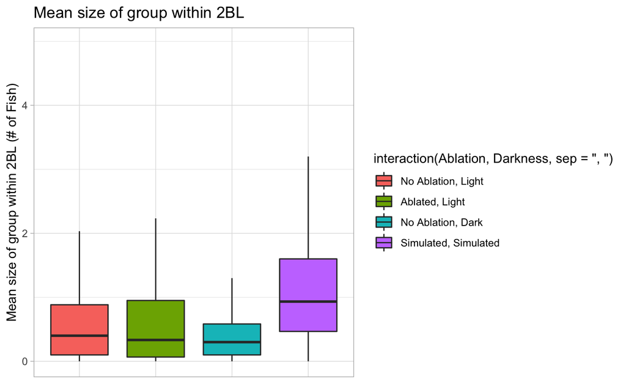

```r
my_comparisons <- list( c("No Ablation, Light", "No Ablation, Dark"),
                        c("No Ablation, Light", "Ablated, Light"),
                        c("No Ablation, Dark", "Simulated, Simulated"))

ggplot(time_within_2_simul,
       aes(x = interaction(Ablation,Darkness,sep=", "), y = Together_Secs,
           fill = interaction(Ablation,Darkness,sep=", ")))+
  geom_boxplot(outlier.shape = NA) +
  #guides(fill = guide_legend(title = "Condition")) +
  #scale_fill_manual(values=c(light_no_ab_color, light_ab_color, dark_no_ab_color,sim_color)) +
  ggtitle("Mean size of group within 2BL") +
  xlab("") +
  ylab("Mean size of group within 2BL (# of Fish)") +
  #sylim(0,9) +
  theme_light() +
  #facet_wrap(~ Flow, strip.position = "bottom")+
  #stat_compare_means(aes(label = ..p.signif..), method = "t.test", ref.group = "Flow 0, No Ablation, Light")
  #stat_compare_means(comparisons = my_comparisons, label.y = c(7.5,8.5,6), label = "p.signif", hide.ns = TRUE) +
  theme(axis.title.x=element_blank(),
        axis.text.x=element_blank(),
        axis.ticks.x=element_blank()) +
  scale_y_continuous(breaks=c(0,2,4,6,8))
```